# UW DS350 Final Project

#### NOx Weekly Concentration

NOx daily levels also follow a similar profile to CO daily levels, though appear perhaps more even from Wednesday through Friday.

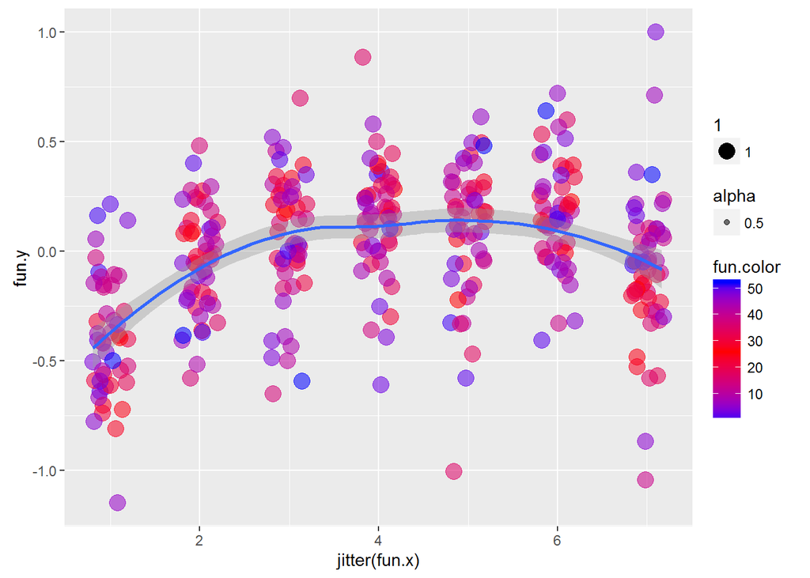

Once again, Sunday (1) stands out for significantly lower NOx levels. We see that Wednesday and Friday (4 & 6) are significantly higher than Sunday, Monday, and Saturday (1, 2, 7).

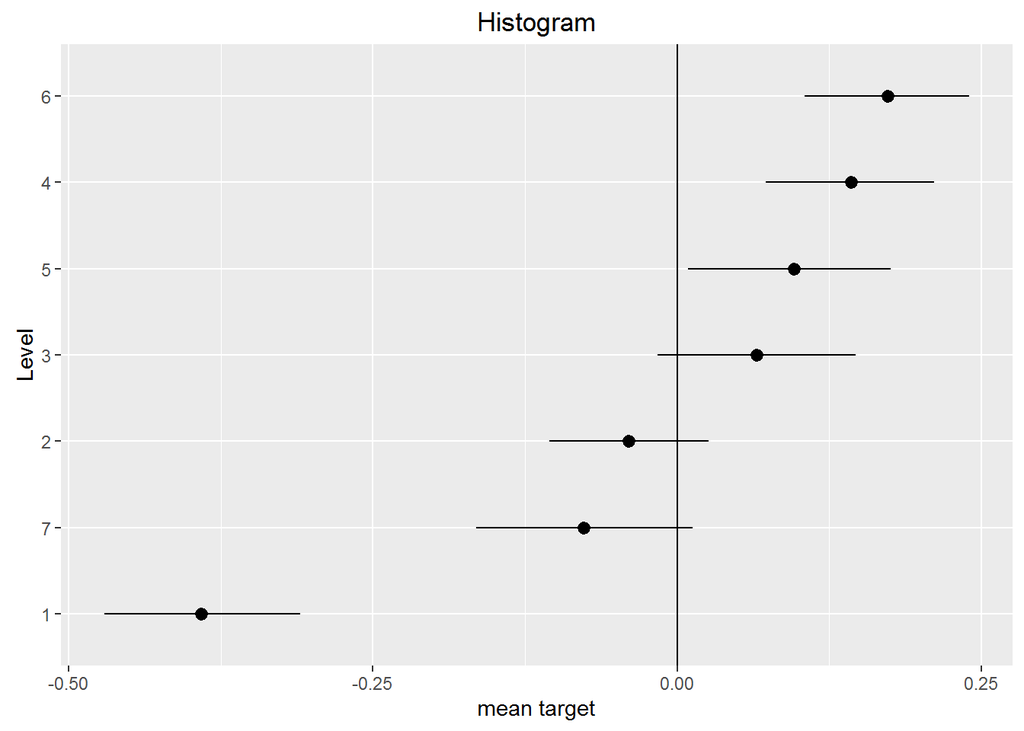

ANOVA shows similar trends, with Sunday (1) standing out as significantly lower than all other days of the week.

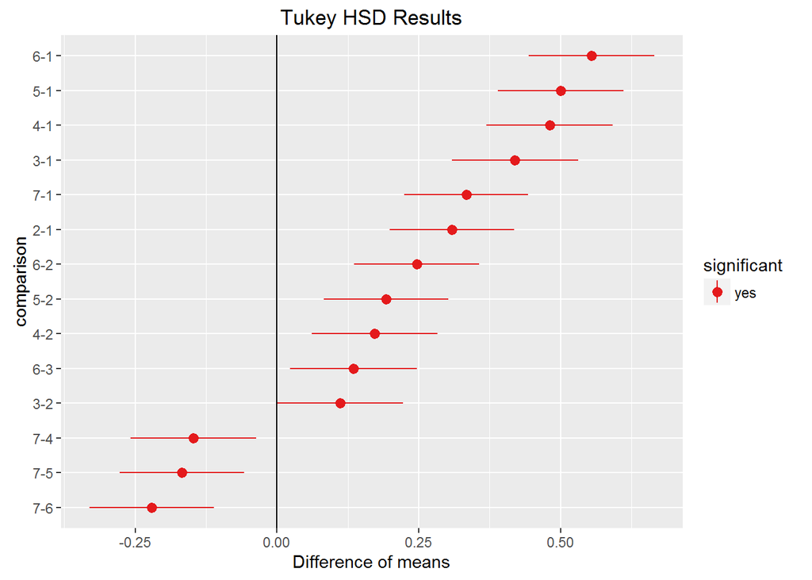